# Where Did You Get Sick?

Place, mobility, time, and uncertainty in public health

Eric Delmelle

First Year Seminar · Wicked Problems in Health · College of Health, Lehigh University

October 23, 2026

## Your homework

How many places did you list? *1–2 · 3–4 · 5 or more*

If a public-health researcher could put you at **one place** only, which did you choose?

- **A** My home
- **B** Where I spent the most time
- **C** Where exposure was most likely
- **D** Another place
- **E** I don’t have enough information

## What your answer assumes

Your answer What it assumes The follow-up

My home Where you live stands in for what you were exposed to. Convenient, but is it right?

Most time Duration is what matters. Is time alone enough?

Most likely exposure Risk differs from place to place. How would you know?

Not enough information The uncertainty is real. Can a health department wait for it to go away?

## Same illness, five years later

Who **changed** their answer when the illness appeared five years later?

How confident are you that you found the place of **exposure**?

*Very · Somewhat · Not very · Completely uncertain*

## What else would you need to know?

PLACE Where else were you?

TIME When were you there?

EXPOSURE What happened there?

These are exactly the dimensions that **disappear** when a person is represented only by a home address.

## Meet Riverton

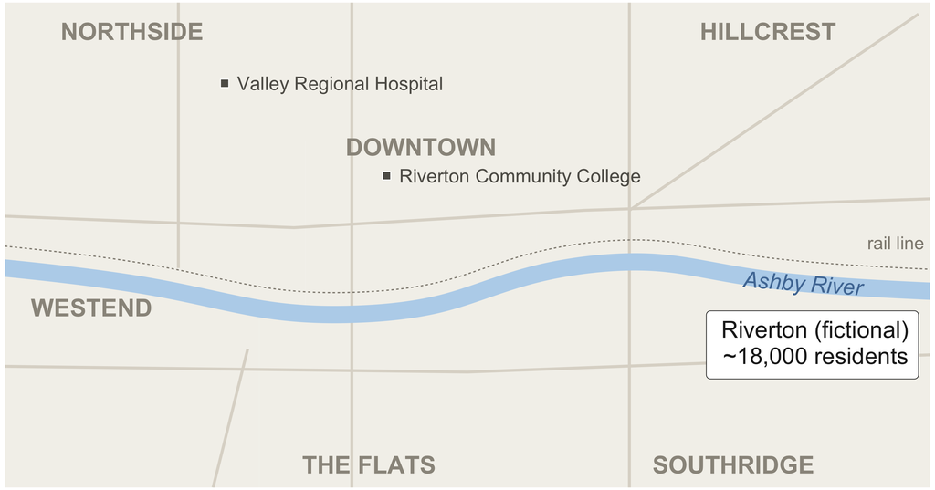

## How a health dataset sees Maya

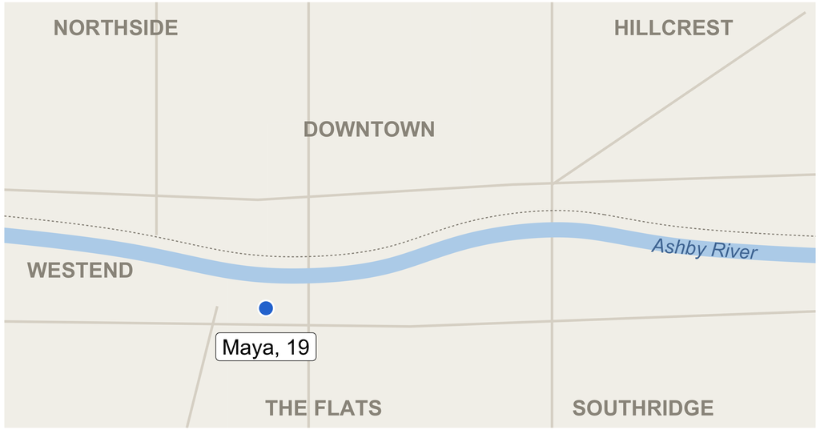

## How Maya actually lives

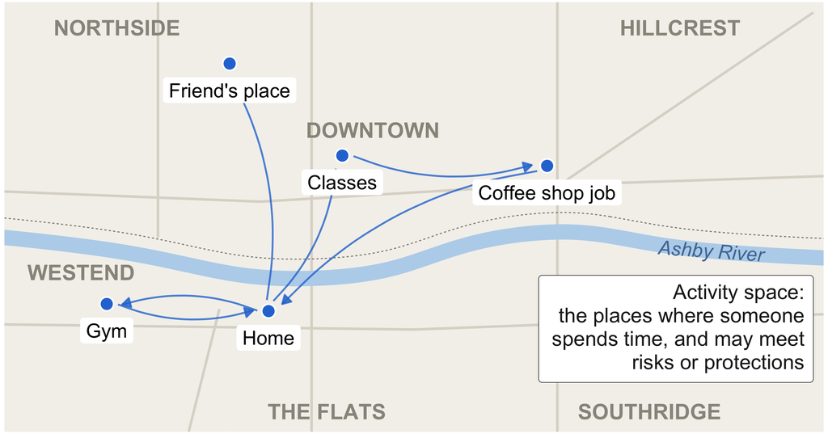

## Maya’s Thursday as a space-time path

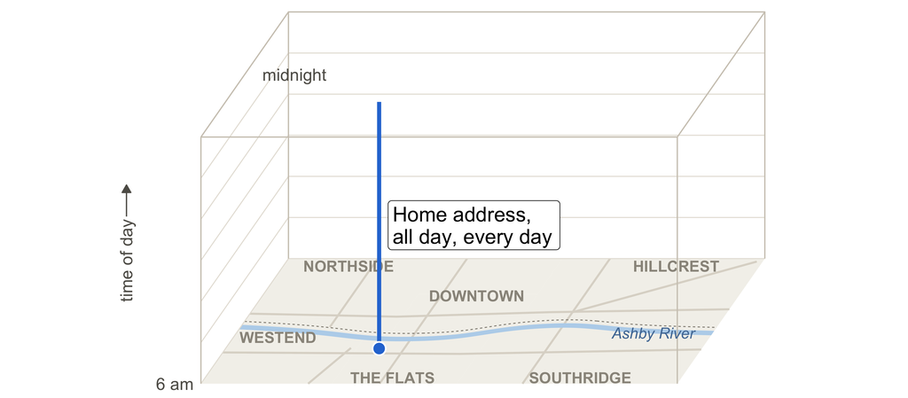

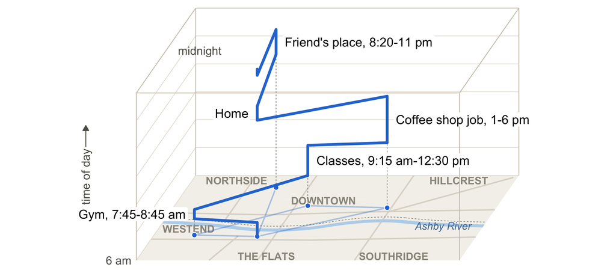

The floor is the map of Riverton; height is the time of day. **Vertical line:** staying in one place. **Sloped line:** moving.

Message 1 of 3

A person is **not a point**.

Health data usually need one location. Your life doesn’t have one.

## What do you think is happening here?

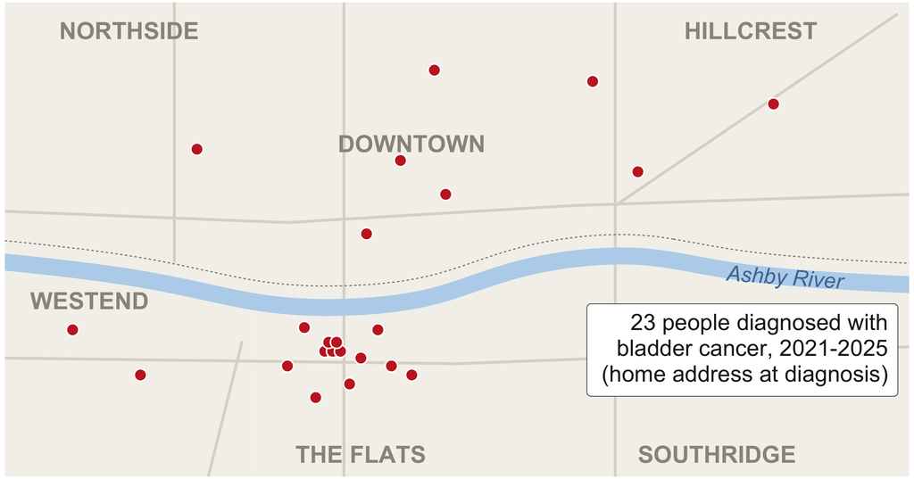

## Before blaming the Flats, what would you want to know?

PLACE Where else did these 23 people live and work?

TIME How long have they lived in the Flats? When could exposure have happened?

EXPOSURE Is there a possible source nearby? Who lives in the Flats: age, smoking?

Expected for a town of 18,000 over five years: **about 22**. Riverton’s total is ordinary. The **concentration** is not: the Flats holds 16% of residents but 13 of 23 cases.

## Your explanation, before more evidence?

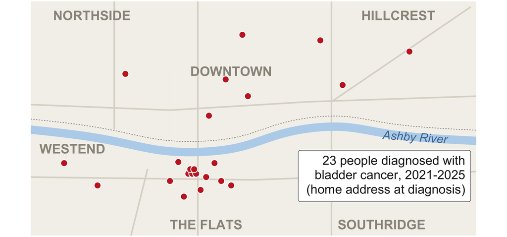

- **A** Something in the Flats
- **B** Chance
- **C** Who lives there
- **D** Can’t tell yet

## Exposure: a former dye plant next door

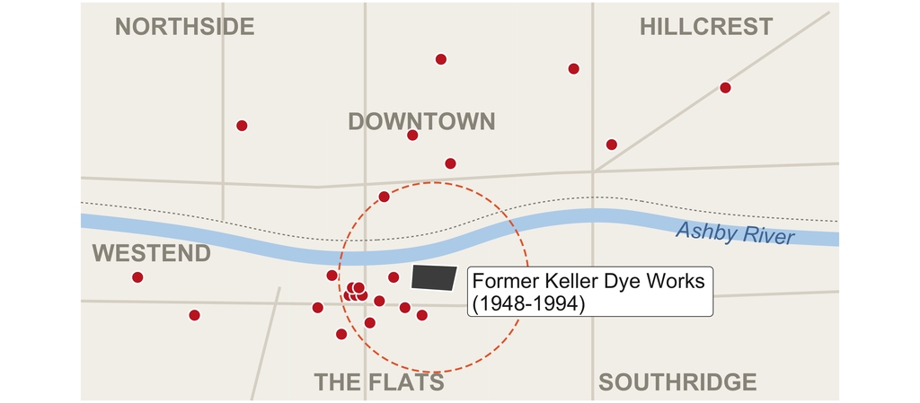

11 of 23 cases live within 1 km (dashed circle). Some chemicals used to make dyes cause bladder cancer in exposed workers. **Has your explanation changed?**

## Place: where they worked

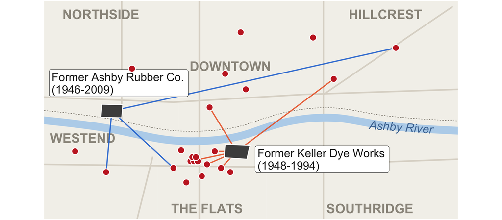

6 cases worked at Keller; 3 at Ashby Rubber, which used related chemicals. 4 of these 9 workers live outside the Flats. **Has your explanation changed?**

## Time: who lives in the Flats now?

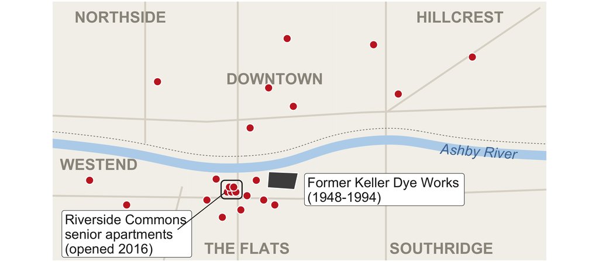

5 cases live in Riverside Commons, a senior building opened in 2016; all moved in after age 65. About 9 in 10 people diagnosed with bladder cancer are over 55. **Has your explanation changed?**

## One of the 23: Frank, 69

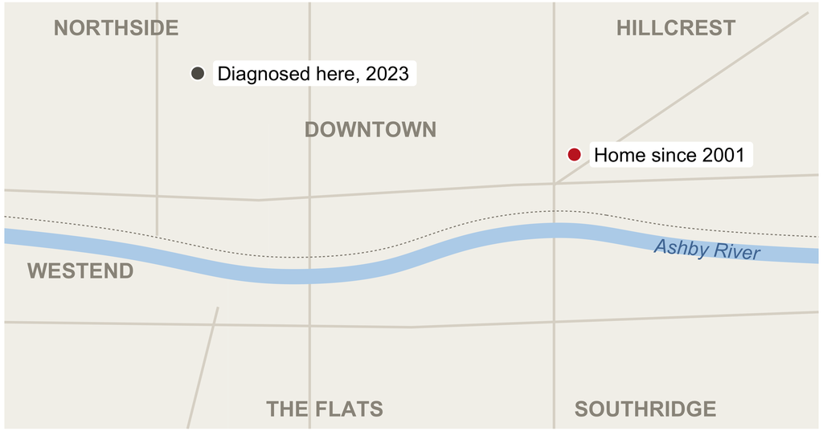

## Frank’s other places

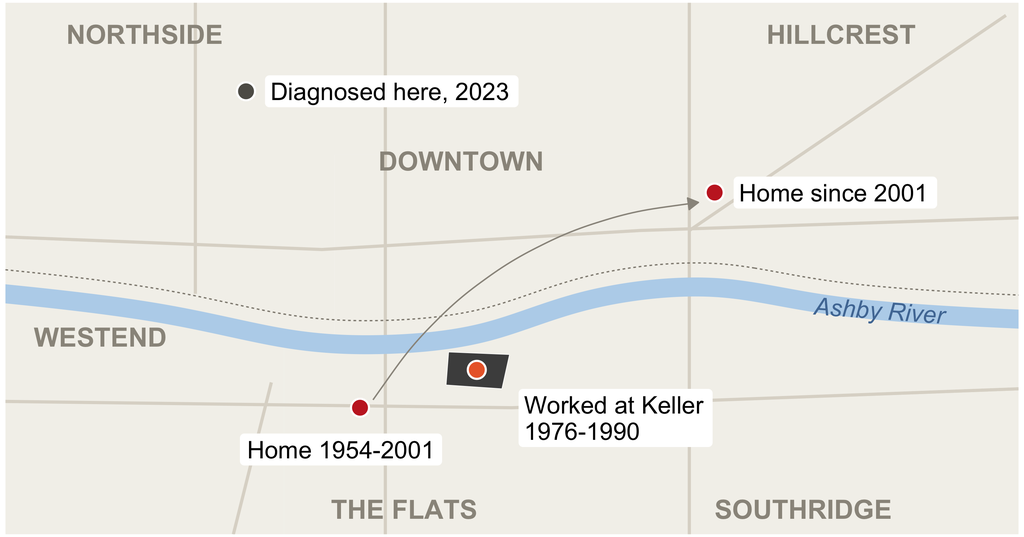

## Frank’s seventy years

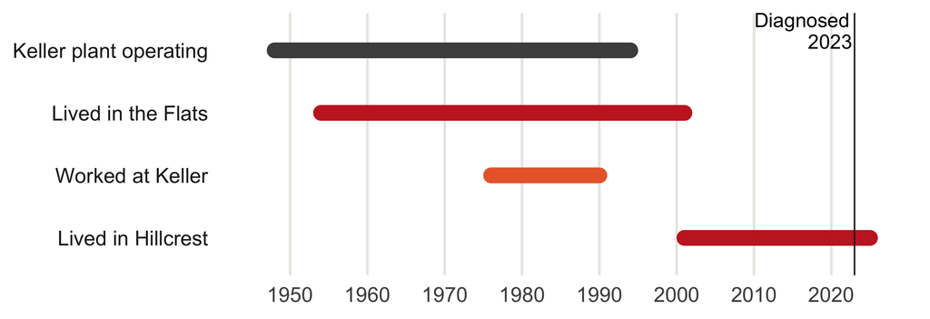

Diagnosed in 2023, about thirty years after he last worked at the plant.

## Where should Frank appear on the map?

A · Where he lives Hillcrest, since 2001

B · Where he was diagnosed Valley Regional Hospital, 2023

C · Where he may have been exposed The Flats and Keller, 1950s–1990s

- **D** More than one of these
- **E** It depends on the question

For many chronic diseases, exposure and diagnosis are separated by **years or decades**. Some workplace chemicals linked to bladder cancer can take 20 years or more to show an effect.

## Time: the same 23 people, in 1985

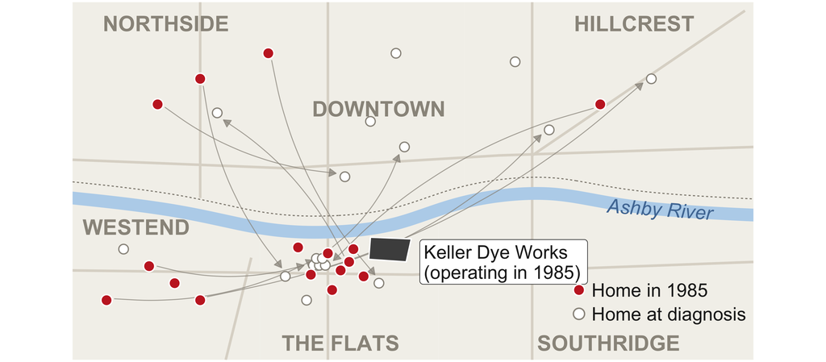

8 lived in the Flats while the plant was running; 3 of them have since moved away. 7 did not live in Riverton at all. **Has your explanation changed?**

## Same cases, four stories

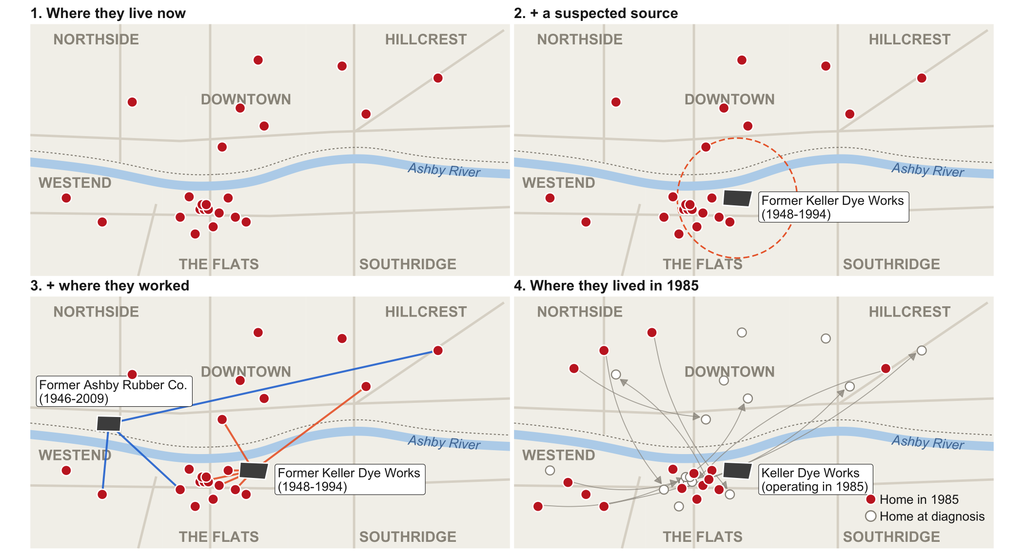

## Change the disease: an infection

**Sam**, Lehigh sophomore, tests positive on Monday for a contagious respiratory infection (think flu or measles).

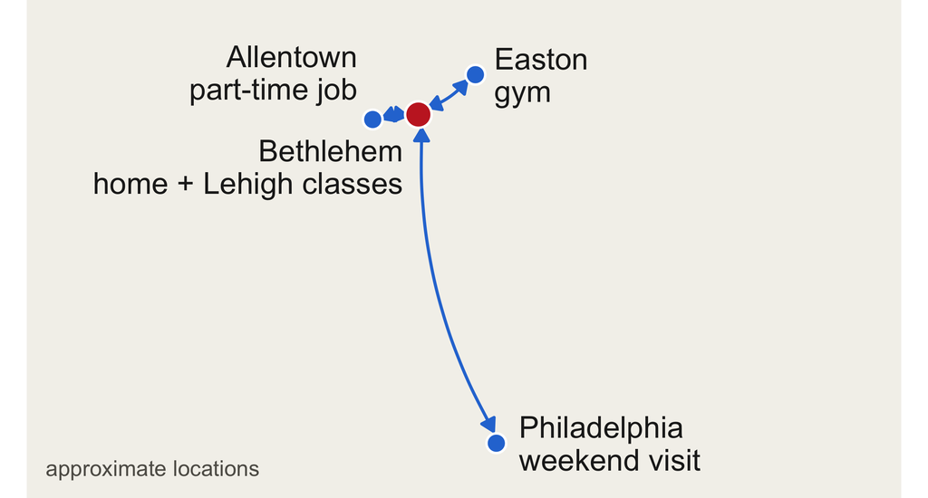

Where did Sam get infected? Where might it spread next?

## Same mobility, different questions

|  | Chronic disease (Frank) | Infection (Sam) |
| --- | --- | --- |
| Time window | Years to decades | Days to weeks |
| Direction | Look backward | Look backward **and** forward |
| Mobility tells us | Where exposure *might* have happened | Where it happened, and where it may go |

Message 2 of 3

Where disease is **diagnosed** is not necessarily where it was **acquired**.

For Frank: decades earlier, across town. For Sam: days earlier, in another city.

## You are the Riverton Health Department

Possible actions

- Test soil, air, and water at the former plant
- Contact former Keller and Ashby workers
- Offer screening
- Collect residential and work histories
- Issue a public warning
- Restrict access to the site
- Keep monitoring

Your call?

- **A** Act now
- **B** Targeted investigation
- **C** Collect more data first
- **D** Routine surveillance

## Acting too early, acting too late

**Too early**

- Fear and stigma for the Flats
- Falling home values; worried landlords and seniors
- Money spent on the wrong problem
- Trust lost if the threat wasn’t real

**Too late**

- Preventable illness continues
- Former workers and families never warned
- Trust lost if officials knew and waited

How certain should we be before taking action? And how much about people’s movements should a health department be allowed to collect?

## Better questions

Where did you get sick?

- Where **could** exposure have occurred?
- **When?**
- **Who else** might have been exposed?
- What evidence would **change** our interpretation?
- When do we know **enough to act**?

## Three messages

1. A person is **not a point**.
2. Where disease is **diagnosed** is not necessarily where it was **acquired**.
3. Decisions still have to be made **under uncertainty**.

In recitation, you are the Riverton Health Department.